# LA with RcppArmadillo

## Model Checking

We can now plot fitted values and the residuals to check if the model seems valid:

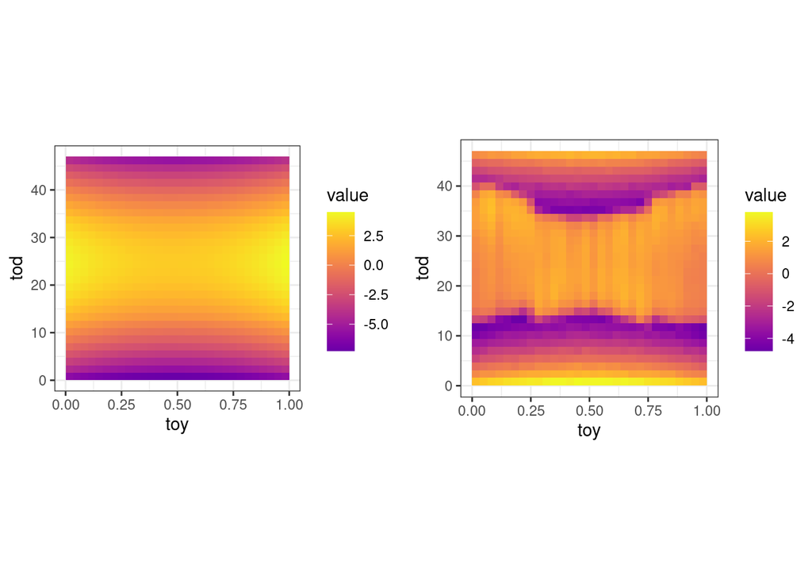

```r
library(gridExtra)

solarAU <- solarAU %>%
  mutate(fitted = fit$fitted.values,
         residuals = fit$residuals)

fitted_plot <- ggplot(data = solarAU,
                      aes(x = toy, y = tod, z = fitted)) +
  stat_summary_2d()+
  theme(aspect.ratio = 1)

res_plot <- ggplot(data = solarAU,
                      aes(x = toy, y = tod, z = residuals)) +
  stat_summary_2d()+
  theme(aspect.ratio = 1)

grid.arrange(fitted_plot, res_plot, ncol = 2)
```

We can see from these plots there is a non linear pattern, particularly in the residuals, so we adapt the model.

# Kernel Local Least Regression

In this model we take the coefficients to be dependent on the covariates $\hat \beta = \hat \beta(x)$. For a fixed $x_0$, we take
$$\hat \beta (x_0) = \mathop{\mathrm{arg\,min}}_{\beta} \sum_{i =1}^n
\kappa_H (x_0 - x_i) (y_i - \tilde x_i^T \beta)^2$$

for a kernel $\kappa_H$ with bandwidth H. We create this function in R:

```r
library(mvtnorm)

lm_local <- function(y, x0, X0, x, X, H){
  w <- dmvnorm(x, x0, H)
  fit <- lm(y ~ -1 + X, weights = w)
  return( t(X0) %*% coef(fit) )
}
```

To reduce the computational cost, we will only fit the model on 2000 data points:

```r
sample_ind <- sample(1:nrow(solarAU), 2000)

x <- solarAU %>%
  select(tod, toy) %>%
  as.matrix()
x_sample <- x[sample_ind,]
X_sample <- X[sample_ind,]

y_sample <- solarAU$logProduction

solar_sample <- solarAU[sample_ind,]

X_sample <- X[sample_ind,]
```

We can now fit $\hat \beta (x_0)$ for each sample data point:

```r
pred_local <- sapply(1:2000, function(ii){
  lm_local(y = y, x0 = x_sample[ii, ], X0 = X_sample[ii, ], x = x, X = X, H = diag(c(1, 0.1)^2))
})
```

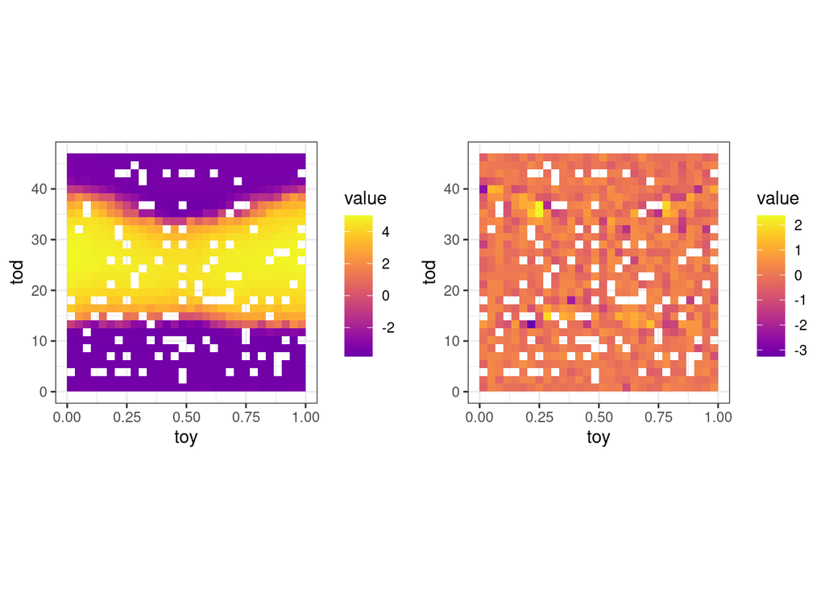

```r
solar_sample <- solar_sample %>%
  mutate("local fitted" = pred_local,
         residuals = logProduction - `local fitted`)

local_fitted_plot <- ggplot(solar_sample,
       aes(x = toy, y = tod, z = `local fitted`)) +
       stat_summary_2d() +
       theme(aspect.ratio = 1)

local_res_plot <- ggplot(solar_sample,
       aes(x = toy, y = tod, z = residuals)) +
       stat_summary_2d() +
       theme(aspect.ratio = 1)

grid.arrange(local_fitted_plot, local_res_plot, ncol = 2)
```